# MH4500 Lab2

# Lab2

## Part 1

```r
# Read Data
global = scan("globtemp.dat")

# Save into PDF File
pdf("globalplot.pdf")
plot.ts(global)
dev.off()
```

```r
# Get Diff
globaldiff = diff(global)
# Diff Plot
pdf("globaldiffplot.pdf")
plot.ts(globaldiff)
dev.off()
```

```r
# ACF plot
pdf("globalacf.pdf")
acf(global)
dev.off()
```

```r
# Diff ACF plot
pdf("globaldiffacf.pdf")
acf(globaldiff)
dev.off()
```

## Writing Functions

```r
# Simple Add result
add = function(a,b){
  result=a+b
  return(result)
}

add(2,3)
```

```
## [1] 5
```

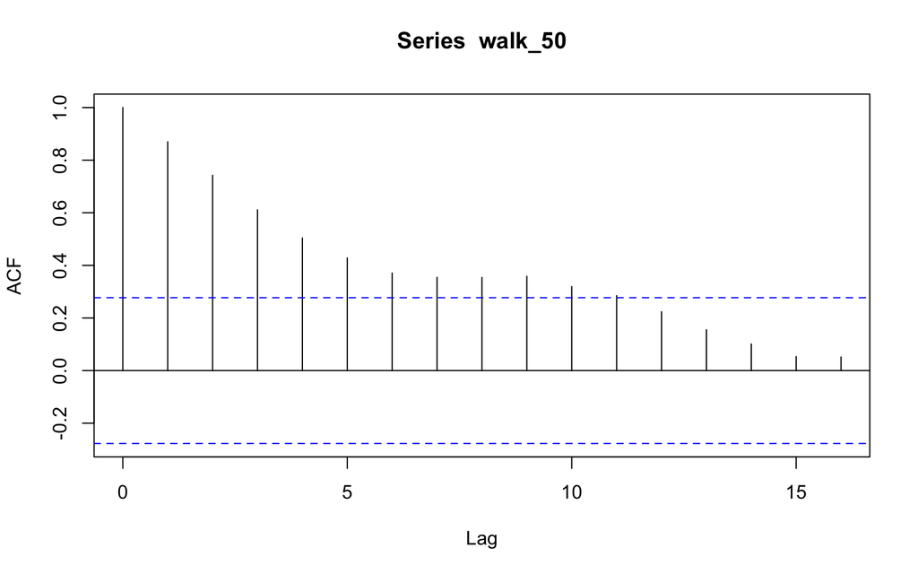

```r
# Random Walk

randomwalk = function(sigsq, T){
  x = rep(0,T)
  w = rnorm(T, sd=sqrt(sigsq))
  for (i in 2:T){
    x[i] = x[i-1] + w[i]
  }
  return(x)
}

walk_50 <- randomwalk(1, 50)
acf(walk_50)
```

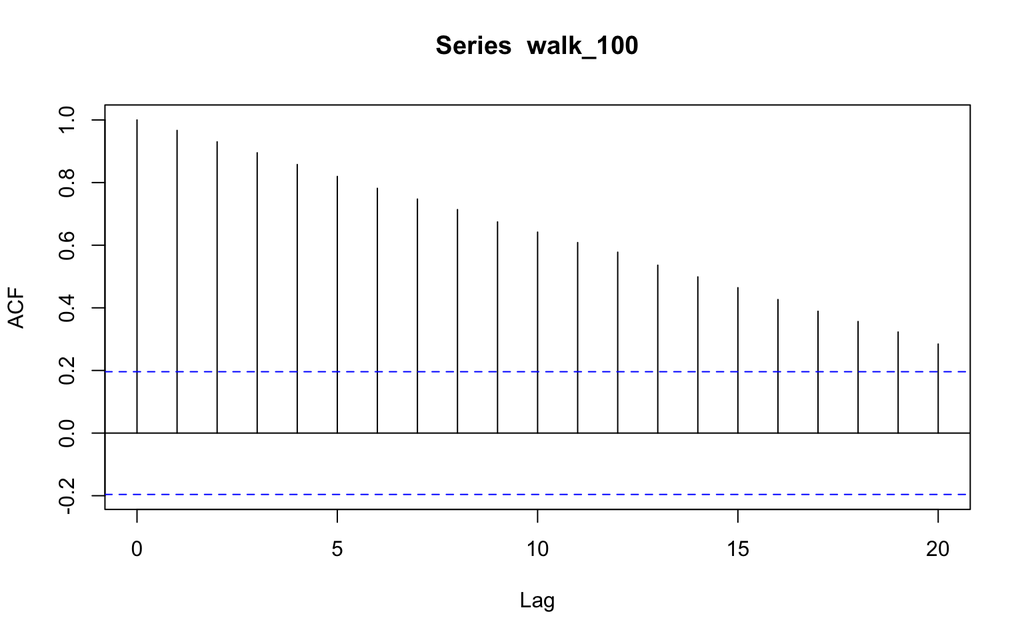

```r
walk_100 <- randomwalk(1, 100)
acf(walk_100)
```

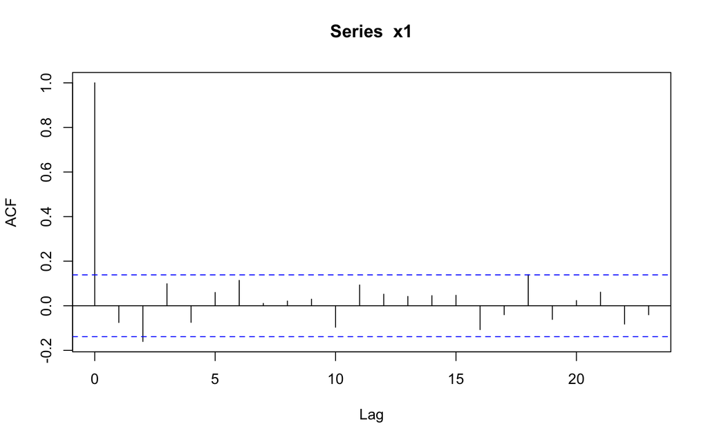

```r
arsim = function(phis, sigsq, T){
  p <- length(phis)
  noise <- rnorm(T+p, sd=sqrt(sigsq))
  x = c(noise[1:p], rep(0, T))
  for ( i in (p+1) : (T+p)) {
    x[i] = phis %*% x[i-(1-p)] + noise[i]
  }
  x=x[(p+1):(T+p)]
  return(x)
}

x1 <- arsim(c(0.5), 1, 200)
acf(x1)
```

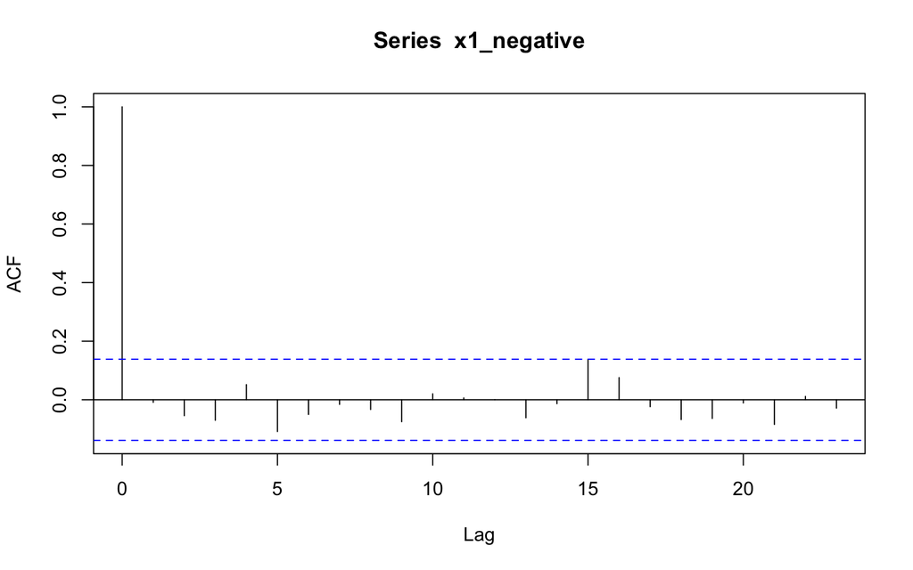

```r
x1_negative <- arsim(c(-0.5), 1, 200)
acf(x1_negative)
```

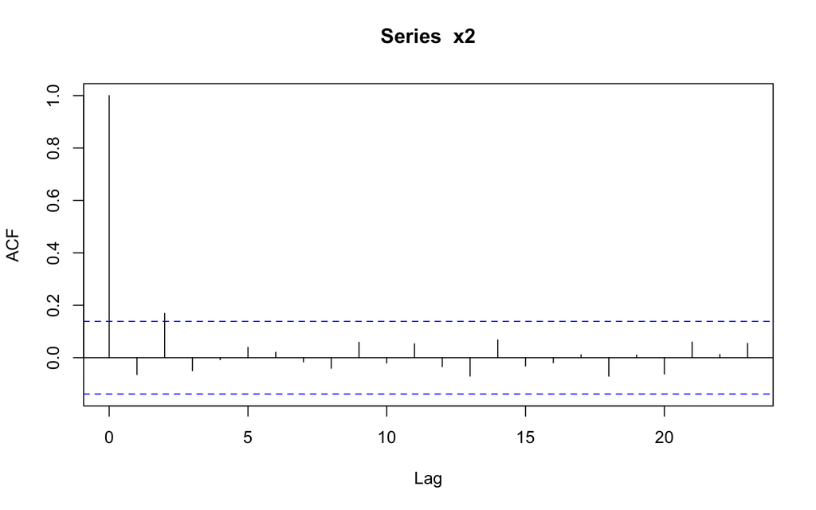

```r
x2 <- arsim(c(1.1), 1, 200)
acf(x2)
```

# Homework

## Question 1

The masim function generates a simulated Moving Average (MA) process of order q based on specified parameters. The function models a time series where each observation is a linear combination of past white noise terms, weighted by given MA coefficients (theta values).

Function Arguments: - thetas: A numeric vector of length q, representing the MA coefficients - sigsq: A positive numeric value representing the variance of the white noise process. - T: An integer specifying the length of the simulated time series.

```r
# Question 1
masim <- function(thetas, sigsq, T){
  # Get number of Q
  q <- length(thetas)
  # Initialize noise
  noise <- rnorm(T + q, sd=sqrt(sigsq))
  x <- rep(0, T)
  # Generate the MA(q) process
  for (t in 1:T) {
    x[t] <- sum(thetas * noise[t + (q:1)])  # Proper lagging of noise
  }
  return(x)
}
```

## Question 2

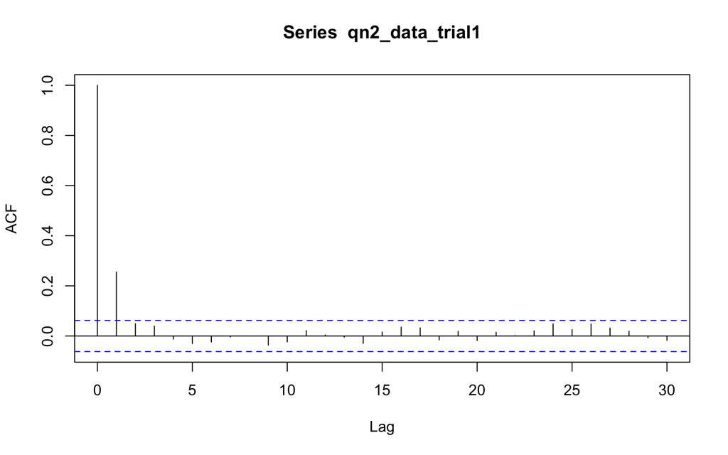

```r
# Trial 1
qn2_data_trial1 <- masim(c(0.5, 2), 1, 1000)
acf(qn2_data_trial1)
```

We then generated a model with 200 observations and repeated this for a few time. We can see that the width between the dotted blue lines is wider than the 1000 observations. This indicates that the standard deviation is larger for 200 samples

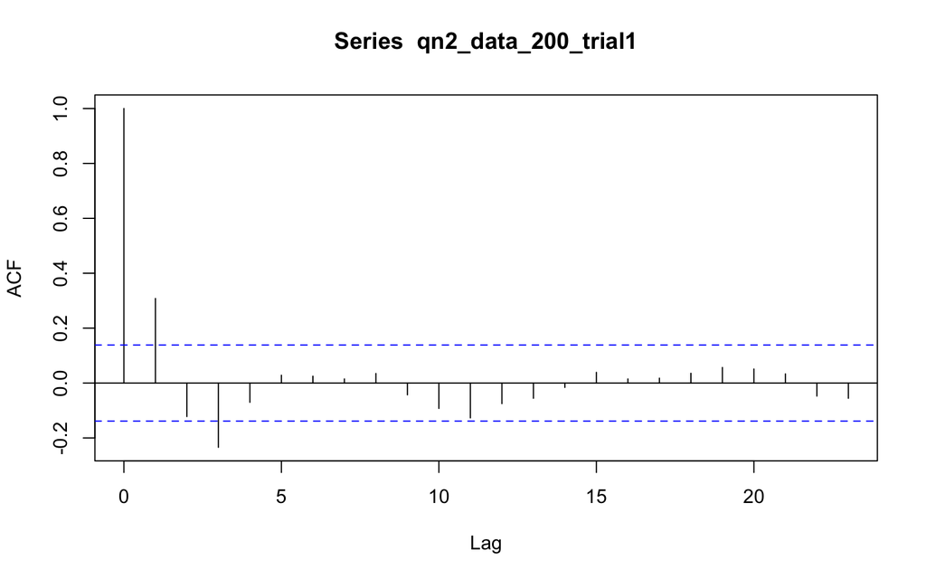

```r
# Trial 1
qn2_data_200_trial1 <- masim(c(0.5, 2), 1, 200)
acf(qn2_data_200_trial1)
```